# Basic Markdown Homework

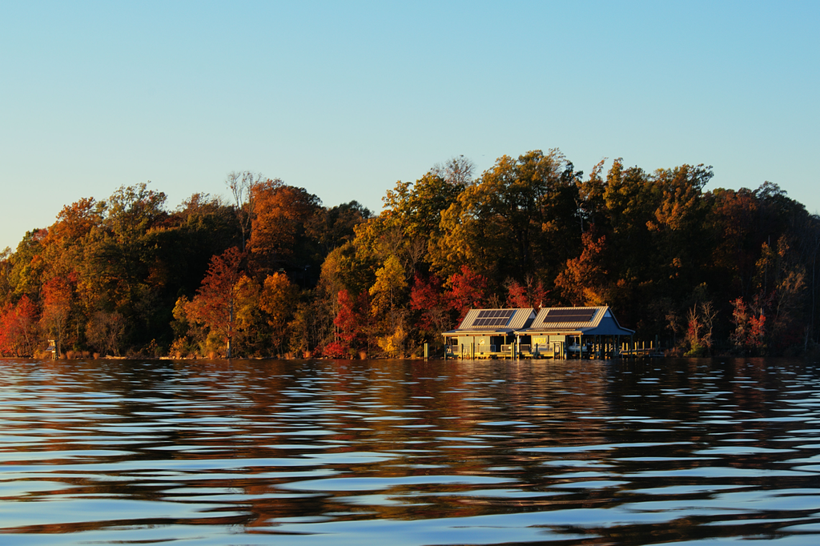

## Objectives

This exercise allows you to demonstrate the following skills:

- Create a professional looking Quarto document
- Demonstrate sufficient mastery to insert and present the most common typographic and multimedia components.
- Add multimedia content to the document.

## Rationale

A fundamental tenet in modern research is keeping the data, analyses, and output as close as possible. One way to do this in `R` is to directly integrate the analyses and visualizations into creating the documents you produce. This may be research reports, presentations, posters, etc. The tighter the link between the document and the underlying data and analyses, the more efficient your actions are. This is why we are starting with Markdown.

Markdown is a method that allows you to focus on the content of your writing rather than the outward display and formatting. It is entirely in text, enabling easy versioning in a system like [Git & GitHub](https://github.com) with robust support across many platforms. The [RStudio](https://posit.co) has a strong support set to allow you to develop a wide array of document types suitable for your work as a scientist. Moreover, it will enable you to embed analysis code (`R`, `Python`, `Julia`, etc.) directly into the body of your document/presentation/report/webpage.

This first step in using Markdown will focus on creating a basic document and presentation. Subsequent learning modules will introduce additional output types and increase the sophistication of the output. This exercise is intended to have you focus on the basics first and as such, we are going to produce something that you are the worlds expert on—you!

## Context

The goal here is for you to create a stand alone document containing your resume and/or curriculum vitae. If you do not have one of theses already, here is your opportunity to get one togehter. If you already have one, then it is going to be even easier for you to to pull something toghter.

In reality, I am not going to be evaluating the *content* of the document, I am using this exerciese so you can have some practical experience developing a document with the most common elements in it. So, if you’d like to whip up your cat’s resume, that is just as acceptable. Try to incorporate appropriate formatting as if you were linking this to your (or your cats) [LinkedIn](https://linkedin.com) profile.

It needs to be able to demonstrate that you can produce a document with the following components:

- A list of some sort (publications, jobs, etc.).
- Headers and written text.
- Typography to include bold, underline, and italic.
- Working links to email/professional profile.
- 50,000 bonus points[^1] if you put in a profile picture.

## Assessment

As we will be using interactive data analytics, we will render our content to HTML instead of DOCX (can’t get an interactive map interface in a word document…). The Rubric also has the following two items relative to your YAML formatting:

1. For the machinery and imagery that you have in your document to transfer properly to me, ensure your YAML content has the `self-contained` option, so your images and all the CSS/Javascript stuff is bundled with the HTML instead of sitting in that folder right next to it on your laptop (and no where near my computer when I’m grading…)
2. It is also helpful if you insert `code-tools` in the YAML, which embeds your original qmd file into the html, making it visible. It inserts that `</> code` popup menu in the upper right side of the HTML (on this page as well, go pop it). This allows me to help you out when evaluating your content because I can see the actual code “behind the scenes” if there are any issues.

Here is a reminder of how that this content is inserted into your YAML. `New Quarto Document` does not add these by default.

```
---
title: Basic Markdown Homework
author: "YOUR NAME HERE"
format:
  html:
    self-contained: true
    code-tools: true
---
```

## Resources

In addition, you may need the following resources on basic markdown formats and the Quarto document system that RStudio uses:  
- [Markdown Grammar](https://www.markdownguide.org/cheat-sheet/).  
- [RStudio & Markdown](https://rmarkdown.rstudio.com/).  
- [Quarto](https://quarto.org/docs/guide/).

## Footnotes

[^1]: This is a slight exageration, but… I made you look at the footnote! If you want to see how this is done in markdown, use the `</> code` popup, look at the entry with the 50,000 bounus points where I put in the footnote marker, and then look at the last line of markdown.